# Câncer de Mama Wisconsin

### Objetivo:

Utilizar Machine Learning para diagnóstico de câncer de mama com base nas características do câncer.

### Dataset:

O dataset foi criado apartir de imagens da massa da mama. A qual descreve características do nucleo da célula presente na imagem.

### Informações sobre os atributos do dataset:

1- ID  
2- Diagnóstico (M = Maligno, B = Benigno)  
3- Valores que foram extraídos das imagens:

- raio (média das distancias do centro até os pontos do perímetro)
- textura (desvio padrão da escala cinza)
- perímetro
- área
- suavidade (variação local no comprimento do raio)
- compacidade ($\frac{perímetro^2}{área - 1.0}$)
- concavidade (gravidade das porções côncavas do contorno)
- pontos de concavidade (número de porções côncavas do contorno)
- simetria
- dimensão fractal ("aproximação costa" - 1)

#### Dataset utilizado: [Breast Cancer Wisconsin (Diagnostic) Data Set](https://archive.ics.uci.edu/ml/datasets/Breast+Cancer+Wisconsin+%28Diagnostic%29)

## Análise das características

```python
import pandas as pd
import numpy as np
```

```python
df=pd.read_csv('data.csv')
df.head()
```

|  | id | diagnosis | radius_mean | texture_mean | perimeter_mean | area_mean | smoothness_mean | compactness_mean | concavity_mean | concave points_mean | ... | texture_worst | perimeter_worst | area_worst | smoothness_worst | compactness_worst | concavity_worst | concave points_worst | symmetry_worst | fractal_dimension_worst | Unnamed: 32 |
| --- | --- | --- | --- | --- | --- | --- | --- | --- | --- | --- | --- | --- | --- | --- | --- | --- | --- | --- | --- | --- | --- |
| 0 | 842302 | M | 17.99 | 10.38 | 122.80 | 1001.0 | 0.11840 | 0.27760 | 0.3001 | 0.14710 | ... | 17.33 | 184.60 | 2019.0 | 0.1622 | 0.6656 | 0.7119 | 0.2654 | 0.4601 | 0.11890 | NaN |
| 1 | 842517 | M | 20.57 | 17.77 | 132.90 | 1326.0 | 0.08474 | 0.07864 | 0.0869 | 0.07017 | ... | 23.41 | 158.80 | 1956.0 | 0.1238 | 0.1866 | 0.2416 | 0.1860 | 0.2750 | 0.08902 | NaN |
| 2 | 84300903 | M | 19.69 | 21.25 | 130.00 | 1203.0 | 0.10960 | 0.15990 | 0.1974 | 0.12790 | ... | 25.53 | 152.50 | 1709.0 | 0.1444 | 0.4245 | 0.4504 | 0.2430 | 0.3613 | 0.08758 | NaN |
| 3 | 84348301 | M | 11.42 | 20.38 | 77.58 | 386.1 | 0.14250 | 0.28390 | 0.2414 | 0.10520 | ... | 26.50 | 98.87 | 567.7 | 0.2098 | 0.8663 | 0.6869 | 0.2575 | 0.6638 | 0.17300 | NaN |
| 4 | 84358402 | M | 20.29 | 14.34 | 135.10 | 1297.0 | 0.10030 | 0.13280 | 0.1980 | 0.10430 | ... | 16.67 | 152.20 | 1575.0 | 0.1374 | 0.2050 | 0.4000 | 0.1625 | 0.2364 | 0.07678 | NaN |

5 rows × 33 columns

```python
df.drop(['id','Unnamed: 32'],axis=1,inplace=True)
df.head()
```

|  | diagnosis | radius_mean | texture_mean | perimeter_mean | area_mean | smoothness_mean | compactness_mean | concavity_mean | concave points_mean | symmetry_mean | ... | radius_worst | texture_worst | perimeter_worst | area_worst | smoothness_worst | compactness_worst | concavity_worst | concave points_worst | symmetry_worst | fractal_dimension_worst |
| --- | --- | --- | --- | --- | --- | --- | --- | --- | --- | --- | --- | --- | --- | --- | --- | --- | --- | --- | --- | --- | --- |
| 0 | M | 17.99 | 10.38 | 122.80 | 1001.0 | 0.11840 | 0.27760 | 0.3001 | 0.14710 | 0.2419 | ... | 25.38 | 17.33 | 184.60 | 2019.0 | 0.1622 | 0.6656 | 0.7119 | 0.2654 | 0.4601 | 0.11890 |
| 1 | M | 20.57 | 17.77 | 132.90 | 1326.0 | 0.08474 | 0.07864 | 0.0869 | 0.07017 | 0.1812 | ... | 24.99 | 23.41 | 158.80 | 1956.0 | 0.1238 | 0.1866 | 0.2416 | 0.1860 | 0.2750 | 0.08902 |
| 2 | M | 19.69 | 21.25 | 130.00 | 1203.0 | 0.10960 | 0.15990 | 0.1974 | 0.12790 | 0.2069 | ... | 23.57 | 25.53 | 152.50 | 1709.0 | 0.1444 | 0.4245 | 0.4504 | 0.2430 | 0.3613 | 0.08758 |
| 3 | M | 11.42 | 20.38 | 77.58 | 386.1 | 0.14250 | 0.28390 | 0.2414 | 0.10520 | 0.2597 | ... | 14.91 | 26.50 | 98.87 | 567.7 | 0.2098 | 0.8663 | 0.6869 | 0.2575 | 0.6638 | 0.17300 |
| 4 | M | 20.29 | 14.34 | 135.10 | 1297.0 | 0.10030 | 0.13280 | 0.1980 | 0.10430 | 0.1809 | ... | 22.54 | 16.67 | 152.20 | 1575.0 | 0.1374 | 0.2050 | 0.4000 | 0.1625 | 0.2364 | 0.07678 |

5 rows × 31 columns

Checando se há valores nulos no dataset

```python
df.info()
```

```
<class 'pandas.core.frame.DataFrame'>
RangeIndex: 569 entries, 0 to 568
Data columns (total 31 columns):
diagnosis                  569 non-null object
radius_mean                569 non-null float64
texture_mean               569 non-null float64
perimeter_mean             569 non-null float64
area_mean                  569 non-null float64
smoothness_mean            569 non-null float64
compactness_mean           569 non-null float64
concavity_mean             569 non-null float64
concave points_mean        569 non-null float64
symmetry_mean              569 non-null float64
fractal_dimension_mean     569 non-null float64
radius_se                  569 non-null float64
texture_se                 569 non-null float64
perimeter_se               569 non-null float64
area_se                    569 non-null float64
smoothness_se              569 non-null float64
compactness_se             569 non-null float64
concavity_se               569 non-null float64
concave points_se          569 non-null float64
symmetry_se                569 non-null float64
fractal_dimension_se       569 non-null float64
radius_worst               569 non-null float64
texture_worst              569 non-null float64
perimeter_worst            569 non-null float64
area_worst                 569 non-null float64
smoothness_worst           569 non-null float64
compactness_worst          569 non-null float64
concavity_worst            569 non-null float64
concave points_worst       569 non-null float64
symmetry_worst             569 non-null float64
fractal_dimension_worst    569 non-null float64
dtypes: float64(30), object(1)
memory usage: 137.9+ KB
```

```python
df['diagnosis']=df['diagnosis'].map({'M':1,'B':0})
df.head()
```

|  | diagnosis | radius_mean | texture_mean | perimeter_mean | area_mean | smoothness_mean | compactness_mean | concavity_mean | concave points_mean | symmetry_mean | ... | radius_worst | texture_worst | perimeter_worst | area_worst | smoothness_worst | compactness_worst | concavity_worst | concave points_worst | symmetry_worst | fractal_dimension_worst |
| --- | --- | --- | --- | --- | --- | --- | --- | --- | --- | --- | --- | --- | --- | --- | --- | --- | --- | --- | --- | --- | --- |
| 0 | 1 | 17.99 | 10.38 | 122.80 | 1001.0 | 0.11840 | 0.27760 | 0.3001 | 0.14710 | 0.2419 | ... | 25.38 | 17.33 | 184.60 | 2019.0 | 0.1622 | 0.6656 | 0.7119 | 0.2654 | 0.4601 | 0.11890 |
| 1 | 1 | 20.57 | 17.77 | 132.90 | 1326.0 | 0.08474 | 0.07864 | 0.0869 | 0.07017 | 0.1812 | ... | 24.99 | 23.41 | 158.80 | 1956.0 | 0.1238 | 0.1866 | 0.2416 | 0.1860 | 0.2750 | 0.08902 |
| 2 | 1 | 19.69 | 21.25 | 130.00 | 1203.0 | 0.10960 | 0.15990 | 0.1974 | 0.12790 | 0.2069 | ... | 23.57 | 25.53 | 152.50 | 1709.0 | 0.1444 | 0.4245 | 0.4504 | 0.2430 | 0.3613 | 0.08758 |
| 3 | 1 | 11.42 | 20.38 | 77.58 | 386.1 | 0.14250 | 0.28390 | 0.2414 | 0.10520 | 0.2597 | ... | 14.91 | 26.50 | 98.87 | 567.7 | 0.2098 | 0.8663 | 0.6869 | 0.2575 | 0.6638 | 0.17300 |
| 4 | 1 | 20.29 | 14.34 | 135.10 | 1297.0 | 0.10030 | 0.13280 | 0.1980 | 0.10430 | 0.1809 | ... | 22.54 | 16.67 | 152.20 | 1575.0 | 0.1374 | 0.2050 | 0.4000 | 0.1625 | 0.2364 | 0.07678 |

5 rows × 31 columns

### Visualizando os dados

```python
import matplotlib.pyplot as plt
import seaborn as sns
%matplotlib inline
```

```python
#Verificando a proporção de cada tipo de câncer
df_prop=df.copy()['diagnosis']
df_prop=pd.get_dummies(df_prop)
df_prop.rename(columns={0:'Benigno',1:'Maligno'},inplace=True)
df_prop=df_prop.sum()
df_prop
```

```
Benigno    357
Maligno    212
dtype: int64
```

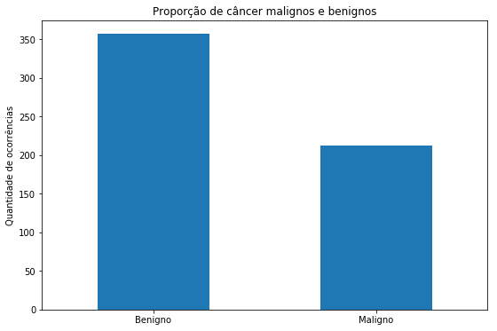

```python
#Criando o gráfico
df_prop.plot(kind='bar',figsize=(9,6),title='Proporção de câncer malignos e benignos',rot=0)
plt.ylabel('Quantidade de ocorrências')
plt.show()
```

Podemos ver que o câncer benigno possui uma proporção maior do que o maligno.

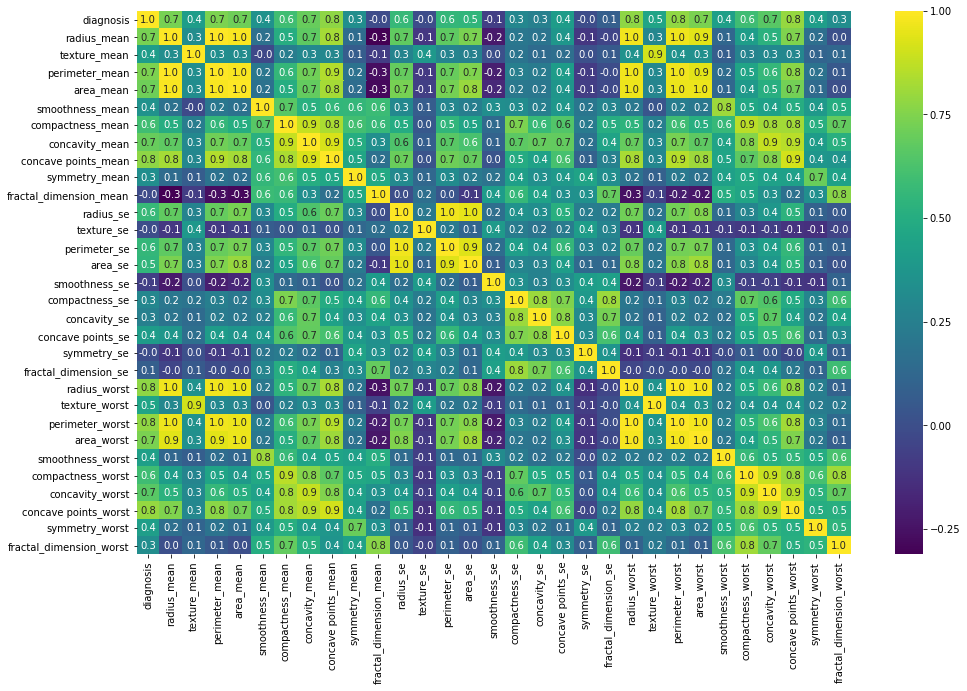

```python
# Criando o mapa de correlação
# Acabei deixando apenas um número depois da vírgula
plt.figure(figsize=(16,10))
sns.heatmap(df.corr(),annot=True,cmap='viridis',fmt = '.1f')
plt.show()
```

Assim podemos verificar quantas aproximadamente características iremos utilizar.

## Pré-Processamento

```python
# Reservei 20% para os testes e 80% para o treinamento
from sklearn.model_selection import train_test_split

X=df.iloc[:,1:]
y=df['diagnosis']
X_train,X_test,y_train,y_test=train_test_split(X, y, test_size=0.2, random_state=0)
print('Training Features Shape: {}'.format(X_train.shape))
print('Training Target Shape: {}'.format(y_train.shape))
print('Test Features Shape: {}'.format(X_test.shape))
print('Test Target Shape: {}'.format(y_test.shape))
```

```
Training Features Shape: (455, 30)
Training Target Shape: (455,)
Test Features Shape: (114, 30)
Test Target Shape: (114,)
```

```python
from sklearn.preprocessing import MinMaxScaler
scaler=MinMaxScaler()
X_train_scaled=scaler.fit_transform(X_train)
X_test_scaled=scaler.fit_transform(X_test)
```

## Feature Selection

```python
# Feature Selection baseada no valor de chi^2
from sklearn.feature_selection import SelectKBest, chi2
select_feature=SelectKBest(chi2,k=10).fit(X_train_scaled,y_train)
```

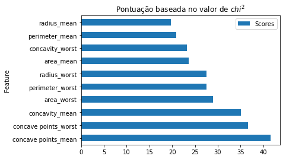

```python
selected_features_df=pd.DataFrame({'Feature':list(X_train.columns),'Scores':select_feature.scores_})
selected_features_df.set_index(['Feature']).sort_values(by='Scores',ascending=False).head(10).plot(
    kind='barh',title='Pontuação baseada no valor de $chi^2$')
```

```python
X_train_chi=select_feature.transform(X_train_scaled)
X_test_chi=select_feature.transform(X_test_scaled)
```

```python
print('Original number of features:',X_train.shape[1])
print('Reduced number of features:',X_train_chi.shape[1])
```

```
Original number of features: 30
Reduced number of features: 10
```

## SVC (Support Vector Classification)

```python
# Criando uma grade de busca para os melhores parametros que podem ser utilizados com SVC
from sklearn.svm import SVC
from sklearn.model_selection import GridSearchCV
from sklearn.model_selection import cross_val_score

parameters={'kernel':('linear','rbf'),'C':[1, 10, 100, 1000],'gamma':[0.0001, 0.001, 0.1, 1, 10, 1000]}
svc=GridSearchCV(SVC(),parameters,cv=5)
svc.fit(X_train_chi,y_train)
best_svc=svc.best_estimator_
```

```python
best_svc
```

```
SVC(C=1000, cache_size=200, class_weight=None, coef0=0.0,
    decision_function_shape='ovr', degree=3, gamma=0.0001, kernel='linear',
    max_iter=-1, probability=False, random_state=None, shrinking=True,
    tol=0.001, verbose=False)
```

```python
print('Acurácia no treinamento: {}'.format(best_svc.score(X_train_chi,y_train)))
print('Acurácia no teste: {}'.format(best_svc.score(X_test_chi,y_test)))
print('Cross-Validation média: {}'.format(cross_val_score(best_svc,X_test_chi,y_test,cv=4).mean()))
```

```
Acurácia no treinamento: 0.9758241758241758
Acurácia no teste: 0.8508771929824561
Cross-Validation média: 0.9390166028097062
```

```python
# Fazendo previsões e criando matriz de confusão para exibição dos dados obtidos do modelo
from sklearn.metrics import confusion_matrix

y_pred=best_svc.predict(X_test_chi)
confusion=confusion_matrix(y_test,y_pred)
confusion
```

```
array([[50, 17],
       [ 0, 47]], dtype=int64)
```

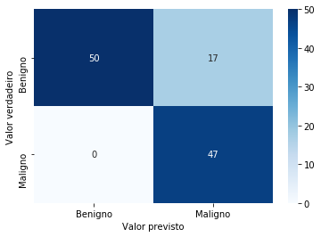

```python
types=['Benigno','Maligno']
sns.heatmap(confusion, annot=True, cmap=plt.cm.Blues, xticklabels=types, yticklabels=types)
plt.xlabel('Valor previsto')
plt.ylabel('Valor verdadeiro')
plt.show()
```

## Naive Bayes

```python
# Utilizando Gaussian Naive Bayes para criação de modelo preditivo
from sklearn.naive_bayes import GaussianNB

nb=GaussianNB()
nb.fit(X_train_chi,y_train)
```

```
GaussianNB(priors=None, var_smoothing=1e-09)
```

```python
print('Acurácia no treinamento: {}'.format(nb.score(X_train_chi,y_train)))
print('Acurácia no teste: {}'.format(nb.score(X_test_chi,y_test)))
print('Cross-Validation média: {}'.format(cross_val_score(nb,X_test_chi,y_test,cv=5).mean()))
```

```
Acurácia no treinamento: 0.945054945054945
Acurácia no teste: 0.8596491228070176
Cross-Validation média: 0.9393939393939394
```

## Random Forest

```python
# Utilizando uma grade de busca para os melhores parametros que foram passados que devolvam uma acurácia alta utilizando
# Random Forest para classificação
from sklearn.ensemble import RandomForestClassifier

parameters={'n_estimators':[10,50,100],'criterion':['gini','entropy']}
rf=GridSearchCV(RandomForestClassifier(random_state=32),parameters,cv=4)
rf.fit(X_train_chi,y_train)
best_rf=rf.best_estimator_
```

```python
best_rf
```

```
RandomForestClassifier(bootstrap=True, class_weight=None, criterion='entropy',
                       max_depth=None, max_features='auto', max_leaf_nodes=None,
                       min_impurity_decrease=0.0, min_impurity_split=None,
                       min_samples_leaf=1, min_samples_split=2,
                       min_weight_fraction_leaf=0.0, n_estimators=50,
                       n_jobs=None, oob_score=False, random_state=32, verbose=0,
                       warm_start=False)
```

```python
print('Acurácia no treinamento: {}'.format(best_rf.score(X_train_chi,y_train)))
print('Acurácia no teste: {}'.format(best_rf.score(X_test_chi,y_test)))
print('Cross-Validation média: {}'.format(cross_val_score(best_rf,X_test_chi,y_test,cv=5).mean()))
```

```
Acurácia no treinamento: 0.9978021978021978
Acurácia no teste: 0.9385964912280702
Cross-Validation média: 0.931060606060606
```

```python
# Fazendo previsões e utilizando matriz de confusão para exibição dos dados obtidos do modelo
y_pred=best_rf.predict(X_test_chi)
confusion=confusion_matrix(y_test,y_pred)
confusion
```

```
array([[60,  7],
       [ 0, 47]], dtype=int64)
```

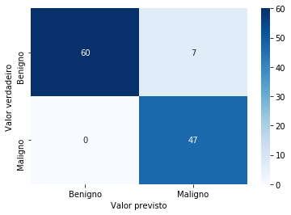

```python
types=['Benigno','Maligno']
sns.heatmap(confusion, annot=True, cmap=plt.cm.Blues, xticklabels=types, yticklabels=types)
plt.xlabel('Valor previsto')
plt.ylabel('Valor verdadeiro')
plt.show()
```

## Conclusão:

O que se teve maior perfomance dentre SVC, Naive Bayes e Random Forest foi Random Forest, claro que existem melhorias que podem ser feitas e se possível entre em contato para aplica-las.